# Homework 5

Debi Gonzalez

2025-10-21

### Homework Number 5

We’re going to install a new course.

In R,

library(swirl) install_course(“Exploratory_Data_Analysis”) swirl()

When prompted, ask for a new course and select Exploratory Data Analysis.

Work through 1 – 4 and answer the following questions:

1. Type play() and load the library(car) and library(ggplot2). Print the first five rows of the mpg data frame. Using the str() command print information about this data frame. Do the same using the dim() command. After that, return to swirl() by typing nxt().

```r
# Loading libraries
library(car)
```

```r
library(ggplot2)

# Using the function head() to print the first 5 rows of the mpg data frame.
head(mpg, 5)
```

```
## # A tibble: 5 × 11
##   manufacturer model displ  year   cyl trans      drv     cty   hwy fl    class
##   <chr>        <chr> <dbl> <int> <int> <chr>      <chr> <int> <int> <chr> <chr>
## 1 audi         a4      1.8  1999     4 auto(l5)   f        18    29 p     compa…
## 2 audi         a4      1.8  1999     4 manual(m5) f        21    29 p     compa…
## 3 audi         a4      2    2008     4 manual(m6) f        20    31 p     compa…
## 4 audi         a4      2    2008     4 auto(av)   f        21    30 p     compa…
## 5 audi         a4      2.8  1999     6 auto(l5)   f        16    26 p     compa…
```

```r
# Printing info about data frame
str(mpg)
```

```
## tibble [234 × 11] (S3: tbl_df/tbl/data.frame)
##  $ manufacturer: chr [1:234] "audi" "audi" "audi" "audi" ...
##  $ model       : chr [1:234] "a4" "a4" "a4" "a4" ...
##  $ displ       : num [1:234] 1.8 1.8 2 2 2.8 2.8 3.1 1.8 1.8 2 ...
##  $ year        : int [1:234] 1999 1999 2008 2008 1999 1999 2008 1999 1999 2008 ...
##  $ cyl         : int [1:234] 4 4 4 4 6 6 6 4 4 4 ...
##  $ trans       : chr [1:234] "auto(l5)" "manual(m5)" "manual(m6)" "auto(av)" ...
##  $ drv         : chr [1:234] "f" "f" "f" "f" ...
##  $ cty         : int [1:234] 18 21 20 21 16 18 18 18 16 20 ...
##  $ hwy         : int [1:234] 29 29 31 30 26 26 27 26 25 28 ...
##  $ fl          : chr [1:234] "p" "p" "p" "p" ...
##  $ class       : chr [1:234] "compact" "compact" "compact" "compact" ...
```

```r
dim(mpg)
```

```
## [1] 234  11
```

2. Type play() again. Make a boxplot of mpg$hwy and change the box color to steelblue. Add a horizontal line at 37. Print the command and the plot here.

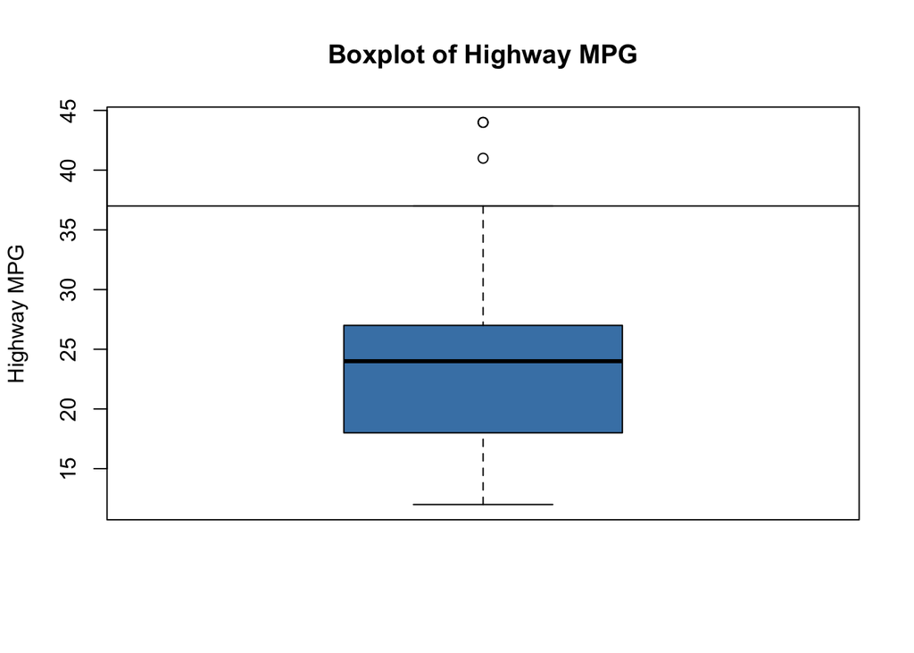

```r
# Creating the boxplot and adding color
boxplot(mpg$hwy, col="steelblue", main = "Boxplot of Highway MPG", ylab = "Highway MPG")
# Adding the line
abline(h = 37)
```

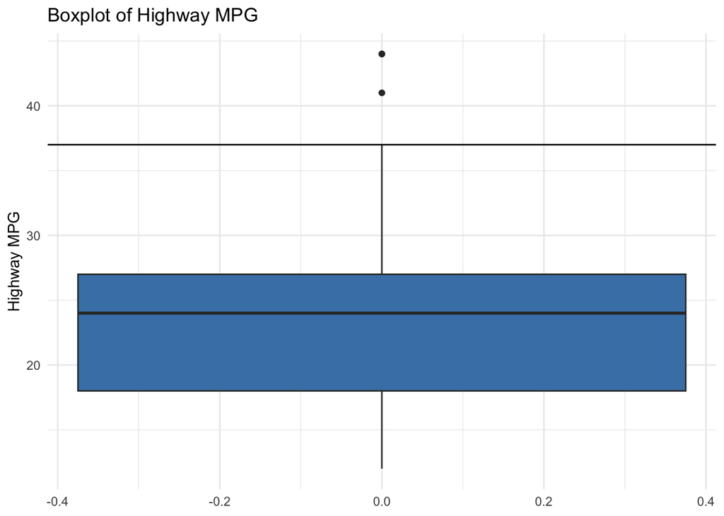

```r
# Creating boxplot in ggplot
ggplot(mpg, aes(y = hwy)) +
  geom_boxplot(fill = "steelblue") +
  geom_hline(yintercept = 37, color = "black") +
  theme_minimal() +
  labs(y = "Highway MPG", title = "Boxplot of Highway MPG")
```

3. Make a histogram of mpg$hwy. Add a vertical line at the median, make it any color you want, but make the lineweight about the size of one of the histogram bins. Print the command and the graph here.

```r
# Checking my data to identify the median
summary(mpg$hwy)
```

```
##    Min. 1st Qu.  Median    Mean 3rd Qu.    Max.
##   12.00   18.00   24.00   23.44   27.00   44.00
```

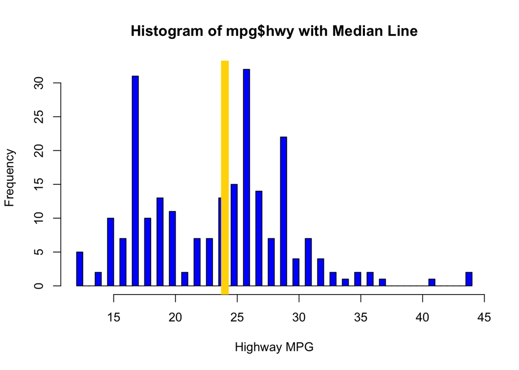

```r
# Making the histogram
hist(mpg$hwy,
     col="blue",
     # Labeling the graph
     main = "Histogram of mpg$hwy with Median Line",
     xlab = "Highway MPG",
     # Making the bins thinner
     breaks = 50)

# Adding the vertical line.
abline(v= median(mpg$hwy), col = "gold", lwd = 10)
```

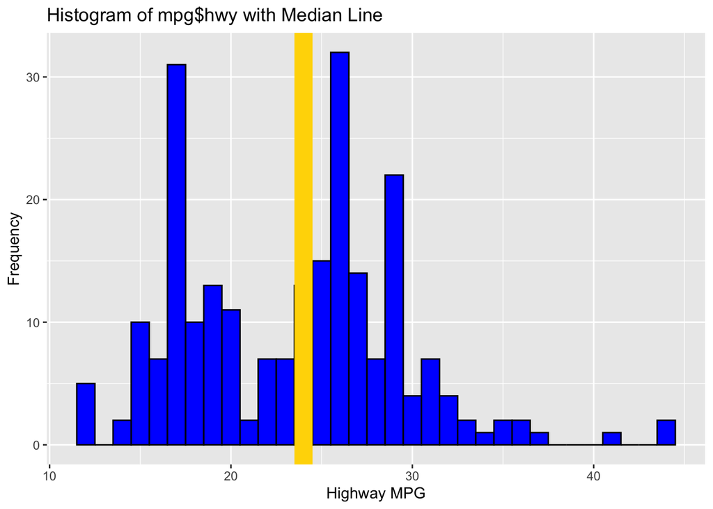

```r
# Now, going to make the histogram with ggplot instead, which I prefer

# Calculating the median of highway mpg to have ready for my graph
med <- median(mpg$hwy, na.rm = TRUE)

# Creating the histogram with a vertical line at the median
ggplot(mpg, aes(x = hwy)) +
  # I'm adding a binwidth so I can later make my vertical line roughly the same size as my bin width.
  geom_histogram(binwidth = 1, fill = "blue", color = "black") +
  # This is the equivalent of the abline, linewidth here is equal to 5 so it's the same size as the bins.
  geom_vline(xintercept = med, color = "gold", linewidth = 6) +
  labs(title = "Histogram of mpg$hwy with Median Line",
       x = "Highway MPG", y = "Frequency")
```

4. Using the table() command, show information about mpg$hwy.

```r
table(mpg$hwy)
```

```
##
## 12 14 15 16 17 18 19 20 21 22 23 24 25 26 27 28 29 30 31 32 33 34 35 36 37 41
##  5  2 10  7 31 10 13 11  2  7  7 13 15 32 14  7 22  4  7  4  2  1  2  2  1  1
## 44
##  2
```

5. subset()is a command I use a lot. Try subsetting ford cars into its own variable from the mpg$manufacturer variable.

```r
# Creating my ford cars subset
ford_cars <- subset(mpg, manufacturer == "ford")

# Checking my variable worked
head(ford_cars)
```

```
## # A tibble: 6 × 11
##   manufacturer model       displ  year   cyl trans drv     cty   hwy fl    class
##   <chr>        <chr>       <dbl> <int> <int> <chr> <chr> <int> <int> <chr> <chr>
## 1 ford         expedition…   4.6  1999     8 auto… r        11    17 r     suv
## 2 ford         expedition…   5.4  1999     8 auto… r        11    17 r     suv
## 3 ford         expedition…   5.4  2008     8 auto… r        12    18 r     suv
## 4 ford         explorer 4…   4    1999     6 auto… 4        14    17 r     suv
## 5 ford         explorer 4…   4    1999     6 manu… 4        15    19 r     suv
## 6 ford         explorer 4…   4    1999     6 auto… 4        14    17 r     suv
```

6. Make a scatterplot of the ford variable, plotting $hwy miles-per-gallon on the x-axis, and $cty miles-per-gallon on the y-axis, using model year as the color.

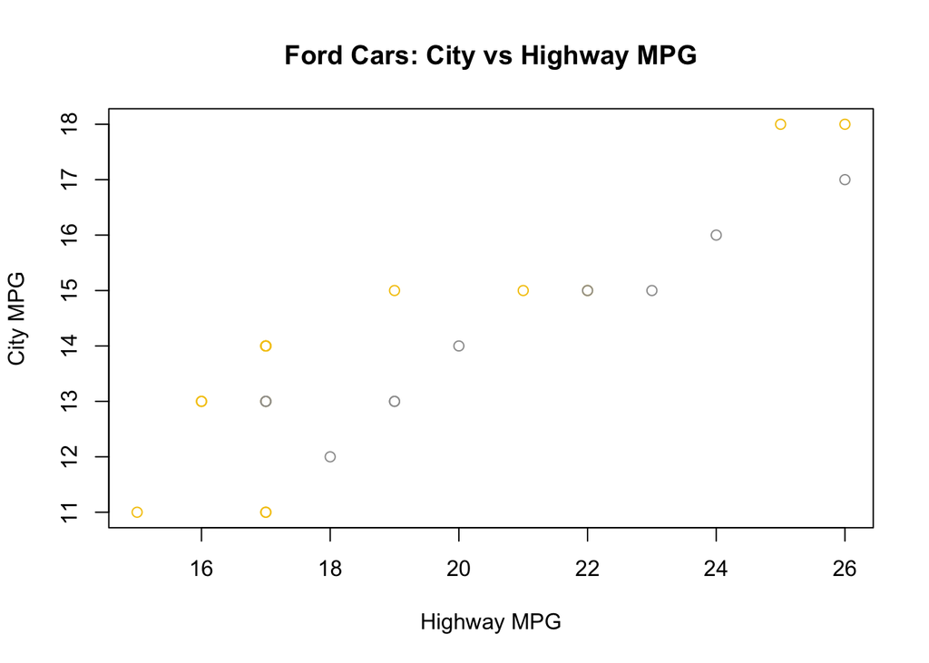

```r
plot(ford_cars$hwy, ford_cars$cty,
     col = ford_cars$year,
     main = "Ford Cars: City vs Highway MPG",
     xlab = "Highway MPG",
     ylab = "City MPG")
```

```r
# See the next question for the ggplot version of this plot.
```

7. Add a title to the plot, and save the plot as a pdf. You only need to print the commands here, not the plot.

```r
# Didn't read ahead, so already had the title and axis labels

# Saving plot to a PDF file
pdf("ford_scatterplot.pdf")

# Recreating the plot
plot(ford_cars$hwy, ford_cars$cty,
     col = ford_cars$year,
     main = "Ford Cars: City vs Highway MPG",
     xlab = "Highway MPG",
     ylab = "City MPG")

# Another way of making the plot

ggplot(ford_cars, aes(x = hwy, y = cty, color = factor(year))) +
  geom_point(size = 3) +
  labs(title = "Ford Cars: City vs Highway MPG",
       x = "Highway MPG",
       y = "City MPG",
       color = "Model Year")

# Both versions will print to the PDF

# Close the PDF device
dev.off()
```

For this section of the homework, we’re going to state the null and alternate hypotheses for a series of questions, and then we’re going to test the hypotheses with R, and generate a conclusion.

Here is an example:

For her science project, a 9-year-old wants to test whether touch therapists can sense energy from an individual’s hand. She has a touch therapist try to sense above which hand the experimenter has placed her own hand (i.e., either the left or the right hand). The therapist cannot see her hands or the experimenter’s hands because both are behind a barrier. Thus, if the therapist does not have a special power to sense the experimenter’s energy, the outcome should have the expected probability of a coin flip.

Answer:

Null/Alternate:

H0:  = .5 HA:  ≠ .5

Experiment and Statistical Test:

The 9-year-old has the therapist conduct 1000 trials of this test. Using the binom.test() in R, the result is 522 correct out of 1000 trials (Note: I just made up the numbers, as you should do in the following questions).

binom.test(522,1000, p = 0.5, alternative = “two.sided”)

```
Exact binomial test
```

data: 522 and 1000 number of successes = 522, number of trials = 1000, p-value = 0.1739 alternative hypothesis: true probability of success is not equal to 0.5 95 percent confidence interval: 0.4905142 0.5533560 sample estimates: probability of success 0.522

Conclusion: The probability of 522 correct guesses out of 1000 trials is 0.1739.

p = 0.1739 > .05. The result is not better than would be expected by chance. We fail to reject the null hypothesis, and conclude that there is no evidence that the therapist can sense the energy of the experimenter’s hand.

Below, in each made up experiment, perhaps follow the woman on her repeated visits to the casino as she works through her gambling addiction. Be creative! Maybe the casino is fixing the games? Maybe not?

1. A woman playing craps at the casino thinks both of the dice she is rolling are biased. She wants to roll a two (i.e., a one on each six-sided die, which are independent). State the null and alternate hypothesis she would need to conduct a test of the bias, conduct the test (using an experiment you made up, stating briefly the details), and state the conclusion.

Null/Alternate:

H0: p = 1/36 = 0.02778 HA: p < 1/36 = 0.02778

Experiment and Statistical Test:

The woman rolls the two dice 1000 times as she would during game play. She expects to get 2 ones at 1/36 (1/6 * 1/6) rate. Using the binom.test() in R, the result is 5 winning rolls (as defined by the woman) out of the 1000 rolls in the test. We use the “less” alternative because we primarily care if the dice are biased against her.

```r
binom.test(5, 1000, p = 1/36, alternative = "less")
```

```
##
##  Exact binomial test
##
## data:  5 and 1000
## number of successes = 5, number of trials = 1000, p-value = 1.102e-07
## alternative hypothesis: true probability of success is less than 0.02777778
## 95 percent confidence interval:
##  0.00000000 0.01048408
## sample estimates:
## probability of success
##                  0.005
```

Conclusion: The probability of 5 winning rolls out of 1000 trials is p=1.102e-07.

p = 1.102e-07 < .05. We reject the null hypothesis, and conclude that there is significant evidence that the outcome of these rolls is biased against the woman as she is rolling the winning combination much less than one would expect by chance.

2. The woman is sick of craps and goes to play the slot machine. She wants to get three sevens on the spin, but she thinks the machine is biased. There are 15 images on each of the spinners, and there are three spinners, which act independently. State the null and alternate hypothesis she would need to conduct a test of the bias, conduct the test (using an experiment you made up, stating briefly the details), and state the conclusion.

Null/Alternate:

H0: p = (1/15)^3 = 0.0002963 HA: p < (1/15)^3 = 0.0002963

Experiment and Statistical Test:

The woman, being very frustrated and therefore dedicated, will run the slot machine 10,000 times. She expects to get 3 sevens on the spin 1 out of 3375 spins. Using the binom.test() in R, the result is 2 jackpots out of the 10,000 spins in her test. We use the “less” alternative because we primarily care if the machine is biased against her.

```r
binom.test(2, 10000, p = (1/15)^3, alternative = "less")
```

```
##
##  Exact binomial test
##
## data:  2 and 10000
## number of successes = 2, number of trials = 10000, p-value = 0.4315
## alternative hypothesis: true probability of success is less than 0.0002962963
## 95 percent confidence interval:
##  0.0000000000 0.0006294441
## sample estimates:
## probability of success
##                  2e-04
```

Conclusion: The probability of 2 jackpots out of 10,000 trials is p=0.4315.

p = 0.4315 > .05. We fail to reject the null hypothesis, and conclude that we lack significant evidence that the outcome of these spins is biased against the woman as her outcomes are within the tolerance of fair probability.

3. Finding that she can’t win at the slot machine, the woman goes to the poker table. The game they are playing is Texas Hold’Em. In this game, each player is dealt two “hole” cards. At the end of the betting rounds, there will be five more cards on the table. Out of the seven cards (table and hole cards), the player will make the best five-card hand.

She has Ace-King of clubs for her hole cards, and she needs one more club to make a flush. There are 13 clubs in the deck. There are two clubs on the table face up, and two additional non-club cards. On the last (fifth) table card, she does not get a club and loses all of her money. The woman leaves the casino thinking the card game was fixed. State the null and alternate hypothesis she would need to conduct a test of the bias, conduct the test (using an experiment you made up, stating briefly the details), and state the conclusion.

Null/Alternate:

H0: p = 9/46 = 0.1956522 The probability of drawing a club if there is no bias in the dealing of cards, meaning the game is fair.

HA: p < 9/46 = 0.1956522 She would care if the game is biased against her (meaning clubs are less likely than expected), which would be p<0.1956522.

Experiment and Statistical Test

The woman will play with this deck 100 times, in which this situation as described occurs. Using the binom.test() in R, we will use the result of 1 game in which she got her clubs out of the 100 rounds in her test. We use the “less” alternative because we primarily care if the machine is biased against her.

```r
binom.test(1, 100, p = 9/46, alternative = "less")
```

```
##
##  Exact binomial test
##
## data:  1 and 100
## number of successes = 1, number of trials = 100, p-value = 8.87e-09
## alternative hypothesis: true probability of success is less than 0.1956522
## 95 percent confidence interval:
##  0.00000000 0.04655981
## sample estimates:
## probability of success
##                   0.01
```

Conclusion: The probability of her getting clubs 1 time over 100 trial games is p=8.87e-09.

p = 8.87e-09 < .05. We reject the null hypothesis, and conclude that we have significant evidence that the the deck may be biased against the woman as her outcomes are not within tolerance of expected fair probability.